# RStudio Exercise 3: Logistic regression

## Data Wrangling

See file `create_alc.R` in [my GitHub repository](https://github.com/opalmen/IODS-project/tree/master/data)

## Data analysis for RStudio Exercise 3

### Install required packages

First, we install the required packages for the analysis: tidyr, ggplot2, GGally, gridExtra (for multiple plots)

```r
install.packages("tidyr", repos = "http://cloud.r-project.org")
install.packages("ggplot2", repos = "http://cloud.r-project.org")
install.packages("GGally", repos = "http://cloud.r-project.org")
install.packages("gridExtra", repos = "http://cloud.r-project.org")
```

and make the packages available

```r
library(tidyr); library(dplyr); library(ggplot2); library(gridExtra)
```

Read data from data folder:

```r
alc <- read.table("C:/Users/palme/Documents/IODS-project/data/alc.csv", sep=",", header=TRUE)
```

Glimpse at the alc data

```r
glimpse(alc)
```

```
## Observations: 382
## Variables: 35
## $ school     <fct> GP, GP, GP, GP, GP, GP, GP, GP, GP, GP, GP, GP, GP,...
## $ sex        <fct> F, F, F, F, F, M, M, F, M, M, F, F, M, M, M, F, F, ...
## $ age        <int> 18, 17, 15, 15, 16, 16, 16, 17, 15, 15, 15, 15, 15,...
## $ address    <fct> U, U, U, U, U, U, U, U, U, U, U, U, U, U, U, U, U, ...
## $ famsize    <fct> GT3, GT3, LE3, GT3, GT3, LE3, LE3, GT3, LE3, GT3, G...
## $ Pstatus    <fct> A, T, T, T, T, T, T, A, A, T, T, T, T, T, A, T, T, ...
## $ Medu       <int> 4, 1, 1, 4, 3, 4, 2, 4, 3, 3, 4, 2, 4, 4, 2, 4, 4, ...
## $ Fedu       <int> 4, 1, 1, 2, 3, 3, 2, 4, 2, 4, 4, 1, 4, 3, 2, 4, 4, ...
## $ Mjob       <fct> at_home, at_home, at_home, health, other, services,...
## $ Fjob       <fct> teacher, other, other, services, other, other, othe...
## $ reason     <fct> course, course, other, home, home, reputation, home...
## $ nursery    <fct> yes, no, yes, yes, yes, yes, yes, yes, yes, yes, ye...
## $ internet   <fct> no, yes, yes, yes, no, yes, yes, no, yes, yes, yes,...
```

[output cut: 22 more lines]

Dataset information:

This dataset contains measures of student achievement of two Portuguese schools. The data include student grades, demographic, social and school related features as additional variables). The dataset provides average performance in two distinct subjects: mathematics and Portuguese language.

The dataset consists of 35 variables and 382 observations

Variables:

1. school - student’s school
2. sex - student’s sex
3. age - student’s age
4. address - urban or rural
5. famsize - family size
6. Pstatus - parent’s cohabitation status
7. Medu - mother’s education
8. Fedu - father’s education
9. Mjob - mother’s job
10. Fjob - father’s job
11. reason - reason to choose this school
12. guardian - student’s guardian
13. traveltime - home to school travel time
14. studytime - weekly study time
15. failures - number of past class failures
16. schoolsup - extra educational support
17. famsup - family educational support
18. paid - extra paid classes
19. activities - extra-curricular activities
20. nursery - attended nursery school
21. higher - wants to take higher education
22. internet - Internet access at home
23. romantic - with a romantic relationship
24. famrel - quality of family relationships
25. freetime - free time after school
26. goout - going out with friends
27. Dalc - workday alcohol consumption 28 Walc - weekend alcohol consumption use
28. Walc - weekend alcohol consumption (numeric: from 1 - very low to 5 - very high)
29. health - health status
30. absences - number of absences
31. G1 - first period average grade (math and portuegese)
32. G2 - second period average grade (math and portuegese)
33. G3 - final period average grade (math and portuegese)
34. alc_use’ - average of ‘Dalc’ and ‘Walc’
35. ‘high_use’ -is TRUE if ‘alc_use’ is higher than 2 and FALSE otherwise

### Analysis of the causes of high alcohol consumption

First we analyze the data, by drawing a bar plot of each variable

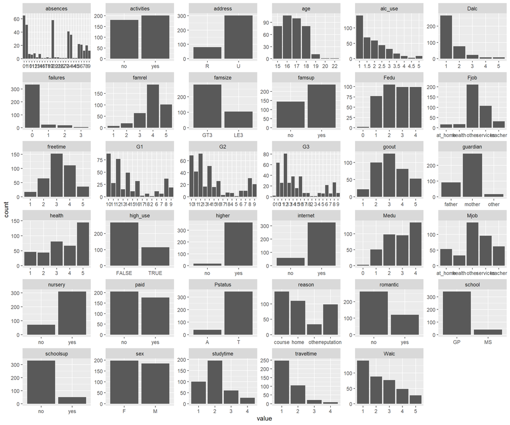

```r
gather(alc) %>% ggplot(aes(value)) + facet_wrap("key", scales = "free") + geom_bar()
```

#### Main hypothesis

There is quite a lot of variation between respondents’ free time and study time, so we use these variables along with age and sex as explanatory variables for alcohol consumption. The main hypothesis is that respondents with a lot of free time also have time to consume alcohol. Moreover, respondents that report many hours of study choose not to consume alcohol, which might decrease their study ability to study. Morever, age might be positively correlated with alcohol consumption, as older respondents drink more than their younger counterparts. Finally, there might be gender differences with respect to alcohol consumption.

We study the relationship between `high_use` and `studytime`, `age`, `freetime`, `sex` First, we produce summary statistics by group

```r
alc %>% group_by(sex, high_use) %>% summarise(count = n(), mean(studytime), mean(age), mean(freetime))
```

```
## # A tibble: 4 x 6
## # Groups:   sex [2]
##   sex   high_use count `mean(studytime)` `mean(age)` `mean(freetime)`
##   <fct> <lgl>    <int>             <dbl>       <dbl>            <dbl>
## 1 F     FALSE      156              2.34        16.6             2.93
## 2 F     TRUE        42              2           16.5             3.36
## 3 M     FALSE      112              1.88        16.3             3.39
## 4 M     TRUE        72              1.64        17.0             3.5
```

Graphical illustration of data:

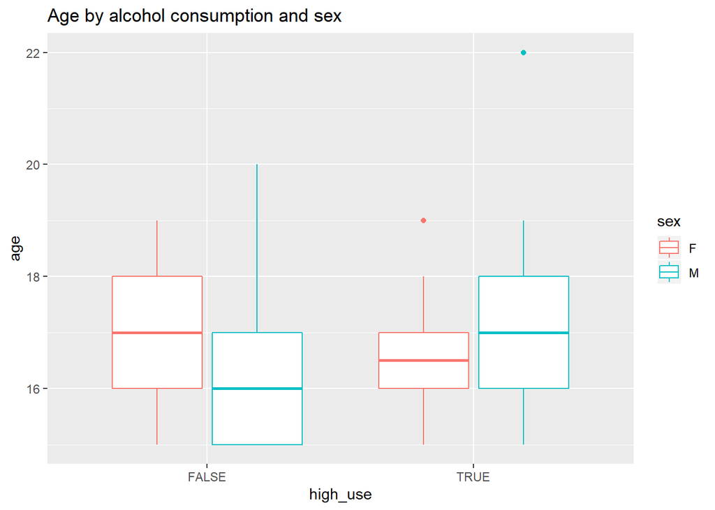

```r
g1 <- ggplot(alc, aes(x = high_use, y = age, col = sex)) #plot high_use and age, separate by sex
g1 + geom_boxplot() + ggtitle("Age by alcohol consumption and sex") # define the plot as a boxplot and draw it
```

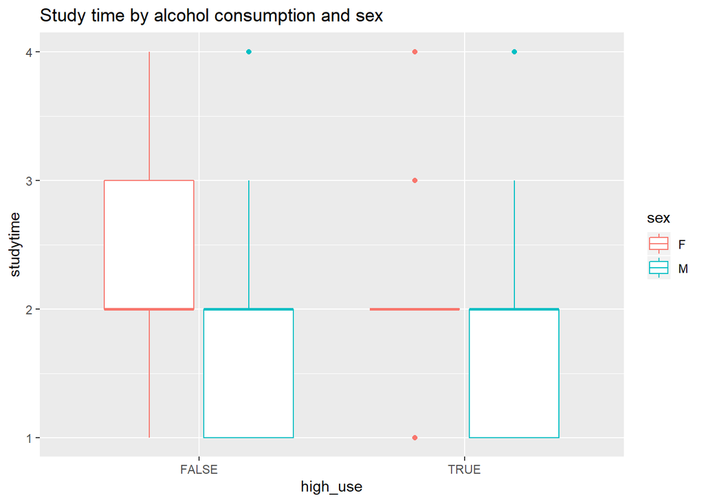

```r
g2 <- ggplot(alc, aes(x = high_use, y = studytime, col = sex)) # plot high_use and freetime by sex

g2 + geom_boxplot() + ggtitle("Study time by alcohol consumption and sex") # define the plot as a boxplot and draw it
```

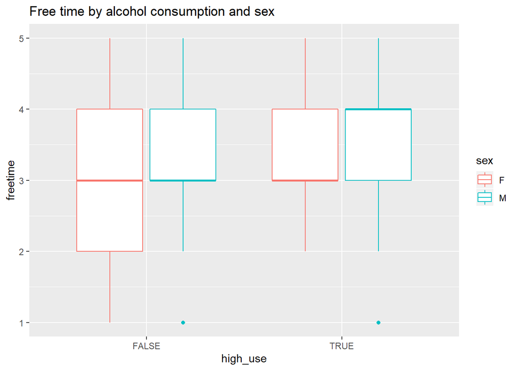

```r
g3 <- ggplot(alc, aes(x = high_use, y = freetime, col = sex)) #plot of high_use and freetime

g3 + geom_boxplot() + ggtitle("Free time by alcohol consumption and sex") # define the plot as a boxplot and draw it
```

#### Logistic regression

Run logistic regression with `high_use` as the dependent variable and `studytime`, `age`, `freetime`, `sex` as explanatory variables

```r
m <- glm(high_use ~ age + studytime + freetime + sex, data = alc, family = "binomial")
```

The summary of the model

```r
summary(m)
```

```
##
## Call:
## glm(formula = high_use ~ age + studytime + freetime + sex, family = "binomial",
##     data = alc)
##
## Deviance Residuals:
##     Min       1Q   Median       3Q      Max
## -1.6526  -0.8509  -0.6602   1.1301   2.2095
##
## Coefficients:
##             Estimate Std. Error z value Pr(>|z|)
## (Intercept)  -4.8768     1.7790  -2.741  0.00612 **
## age           0.2290     0.1011   2.265  0.02349 *
## studytime    -0.4697     0.1602  -2.931  0.00337 **
## freetime      0.2503     0.1229   2.037  0.04166 *
## sexM          0.5854     0.2482   2.359  0.01833 *
## ---
## Signif. codes:  0 '***' 0.001 '**' 0.01 '*' 0.05 '.' 0.1 ' ' 1
##
## (Dispersion parameter for binomial family taken to be 1)
##
##     Null deviance: 465.68  on 381  degrees of freedom
## Residual deviance: 431.41  on 377  degrees of freedom
## AIC: 441.41
##
## Number of Fisher Scoring iterations: 4
```

All coefficients are statistically significant at the 5% level, suggesting that the chosen variables explain alcohol consumption.

Compute the Odds Ratios (OR)

```r
OR <- coef(m) %>% exp
```

and confidence intervals

```r
CI <- confint(m) %>% exp
```

The Odds Ratios and confidence intervals are provided in the table below:

```r
cbind(OR, CI)
```

```
##                      OR        2.5 %    97.5 %
## (Intercept) 0.007621647 0.0002191106 0.2381440
## age         1.257384089 1.0338141044 1.5381420
## studytime   0.625158887 0.4522877516 0.8490039
## freetime    1.284393173 1.0119391550 1.6399589
## sexM        1.795640894 1.1056484552 2.9303141
```

The odds ratios can be interpreted as the change in the odds of high alcohol use given a one unit increase in the explanatory variable. For example, the regression coefficient for `age` is 0.2290334. This indicates that a one unit increase in age increases the odds of being high alcohol use by exp(0.0.2290334)=1.3) times.

To summarize, the amount of free time, age, and being male increase the odds of high alcohol consumption, whereas the amount of study time decreases the odds of high alcohol use, as hypothesized above.

#### Exploring the predictive power of the model

First make the prediction of the prediction

```r
probabilities <- predict(m, type = "response") # predict() the probability of high_use
alc <- mutate(alc, probability = probabilities) # add the predicted probabilities to 'alc'
alc <- mutate(alc, prediction = probability > 0.5) # use the probabilities to make a prediction of high_use
```

and check to see the predictions of the last 10 observations

```r
select(alc, studytime, freetime, age, sex, high_use, probability, prediction) %>% tail(10) # see the last ten original classes, predicted probabilities, and class predictions
```

```
##     studytime freetime age sex high_use probability prediction
## 373         1        3  19   M    FALSE   0.5845170       TRUE
## 374         1        4  18   M     TRUE   0.5896690       TRUE
## 375         3        3  18   F    FALSE   0.1958322      FALSE
## 376         1        4  18   F    FALSE   0.4445380      FALSE
## 377         3        4  19   F    FALSE   0.2822698      FALSE
## 378         2        3  18   F    FALSE   0.2803350      FALSE
## 379         2        2  18   F    FALSE   0.2327073      FALSE
## 380         2        1  18   F    FALSE   0.1910235      FALSE
## 381         1        4  17   M     TRUE   0.5333414       TRUE
## 382         1        4  18   M     TRUE   0.5896690       TRUE
```

#### Predictions vs actual values

```r
table(high_use = alc$high_use, prediction = alc$prediction)
```

```
##         prediction
## high_use FALSE TRUE
##    FALSE   255   13
##    TRUE     95   19
```

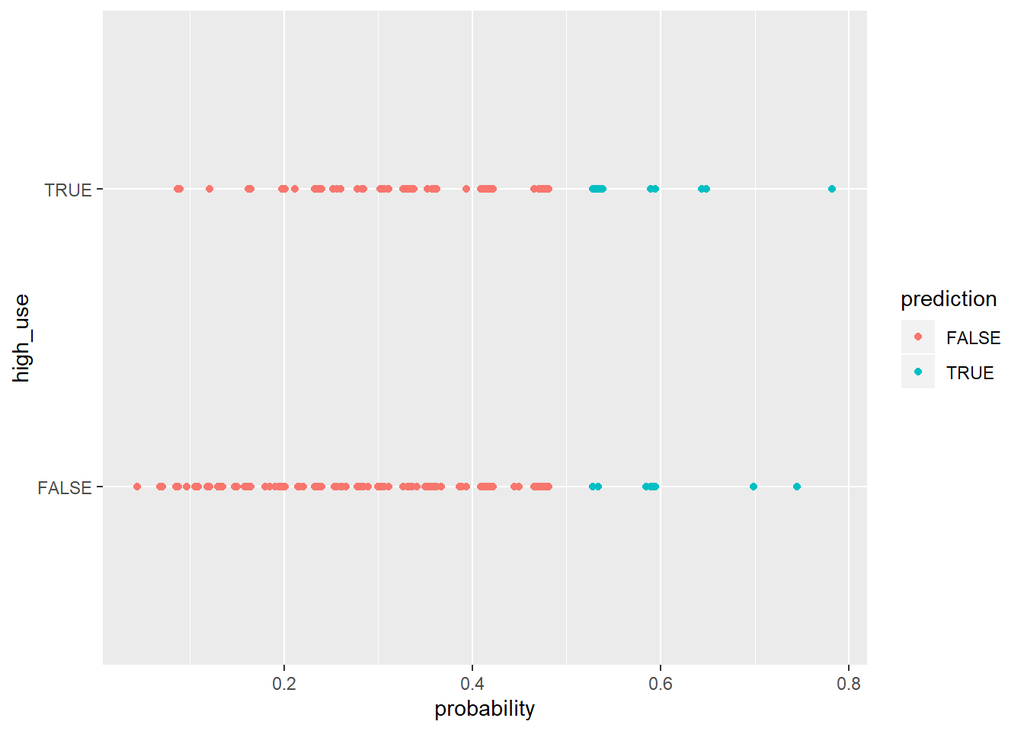

```r
g <- ggplot(alc, aes(x = probability, y = high_use, col = prediction)) # plot 'high_use' versus 'probability' in 'alc'
g + geom_point()
```

```r
# tabulate the target variable versus the predictions
table(high_use = alc$high_use, prediction = alc$prediction) %>% prop.table %>% addmargins
```

```
##         prediction
## high_use      FALSE       TRUE        Sum
##    FALSE 0.66753927 0.03403141 0.70157068
##    TRUE  0.24869110 0.04973822 0.29842932
##    Sum   0.91623037 0.08376963 1.00000000
```

```r
#define a loss function (average prediction error)
  loss_func <- function(class, prob) {
    n_wrong <- abs(class - prob) > 0.5
    mean(n_wrong)
  }
```

There is a high number of false negatives, i.e., that the model predicts low alcohol use, wheras the number of false positives is quite low. However, this suggests that the predictive ability of the model is quite low. This could be adjusted by lowering the acceptance probability of the model.

```r
# call loss_func to compute the average number of wrong predictions in the (training) data
loss_func(class = alc$high_use, prob = alc$probability)
```

```
## [1] 0.2827225
```

```r
# define a loss function (average prediction error)
loss_func <- function(class, prob) {
  n_wrong <- abs(class - prob) > 0.5
  mean(n_wrong)
}
```

```r
# compute the average number of wrong predictions in the (training) data using random predictions
loss_func(class = alc$high_use, prob = runif(length(alc$high_use))>0.5)
```

```
## [1] 0.4424084
```

As the number of predictions goes to infinity, the average share of wrong predictions should be 0.5.

#### Perform K-fold cross-validation

```r
library(boot)
cv <- cv.glm(data = alc, cost = loss_func, glmfit = m, K = 10)
```

```r
m2 <- glm(high_use ~studytime + sex +goout, data = alc, family = "binomial")

summary(m2)
```

```
##
## Call:
## glm(formula = high_use ~ studytime + sex + goout, family = "binomial",
##     data = alc)
##
## Deviance Residuals:
##     Min       1Q   Median       3Q      Max
## -1.7187  -0.8058  -0.5224   0.8849   2.6300
##
## Coefficients:
##             Estimate Std. Error z value Pr(>|z|)
## (Intercept)  -2.7318     0.5683  -4.807 1.53e-06 ***
## studytime    -0.4822     0.1683  -2.865  0.00417 **
## sexM          0.6722     0.2581   2.605  0.00919 **
## goout         0.7519     0.1186   6.340 2.30e-10 ***
## ---
## Signif. codes:  0 '***' 0.001 '**' 0.01 '*' 0.05 '.' 0.1 ' ' 1
##
## (Dispersion parameter for binomial family taken to be 1)
##
##     Null deviance: 465.68  on 381  degrees of freedom
## Residual deviance: 393.95  on 378  degrees of freedom
## AIC: 401.95
##
## Number of Fisher Scoring iterations: 4
```

```r
cv2 <- cv.glm(data = alc, cost = loss_func, glmfit = m2, K = 10)

# average number of wrong predictions in the cross validation
cv2$delta[1]
```

```
## [1] 0.2303665
```